# ES 5-Year Data Analysis

## Project Introduction

This project provides an in-depth analysis of the ES index data over a five-year period. By leveraging historical price and volume data, the analysis seeks to uncover key trends, volatility patterns, and potential future price movements. The project utilizes various statistical methods, visualization techniques, and predictive modeling to achieve the following objectives:

The analysis will be useful for investors, financial analysts, and stakeholders interested in gaining insights into the ES market behavior.

```python
import pandas as pd
import numpy as np
import matplotlib.pyplot as plt
import seaborn as sns
from statsmodels.tsa.arima.model import ARIMA
import warnings

# Suppress specific warnings
warnings.filterwarnings('ignore')
```

## Data Preprocessing

In this section, we preprocess the ES data to ensure it is ready for analysis. We convert the time column to a datetime format, set the frequency, and aggregate the data to a daily frequency. This prepares the dataset for exploratory analysis and modeling.

```python
# Load ES data
es_data = pd.read_csv('ES_5Years_8_11_2024.csv')
es_data['Time'] = pd.to_datetime(es_data['Time'], format='%m/%d/%Y %H:%M')
es_data.set_index('Time', inplace=True)

# Aggregate to daily frequency
es_daily = es_data.resample('D').agg({
    'Open': 'first',
    'High': 'max',
    'Low': 'min',
    'Close': 'last',
    'Volume': 'sum'
})

# Ensure the date index has a frequency set
es_daily.index = es_daily.index.to_period('D')

# Calculate Daily Returns
es_daily['Daily Return'] = es_daily['Close'].pct_change()

es_daily.head()
```

| Time | Open | High | Low | Close | Volume | Daily Return |
| --- | --- | --- | --- | --- | --- | --- |
| 2019-08-11 | 3201.50 | 3210.75 | 3195.75 | 3208.25 | 60219 | NaN |
| 2019-08-12 | 3208.25 | 3213.75 | 3155.25 | 3168.50 | 1669830 | -0.012390 |
| 2019-08-13 | 3168.25 | 3227.00 | 3149.50 | 3209.50 | 2137261 | 0.012940 |
| 2019-08-14 | 3209.25 | 3216.00 | 3116.50 | 3132.00 | 2727073 | -0.024147 |
| 2019-08-15 | 3132.00 | 3154.50 | 3100.50 | 3150.50 | 2429154 | 0.005907 |

## Exploratory Data Analysis (EDA)

We perform EDA to gain insights into the ES price movements and trading volumes over time. This includes visualizing the closing prices, trading volumes, moving averages, and daily returns.

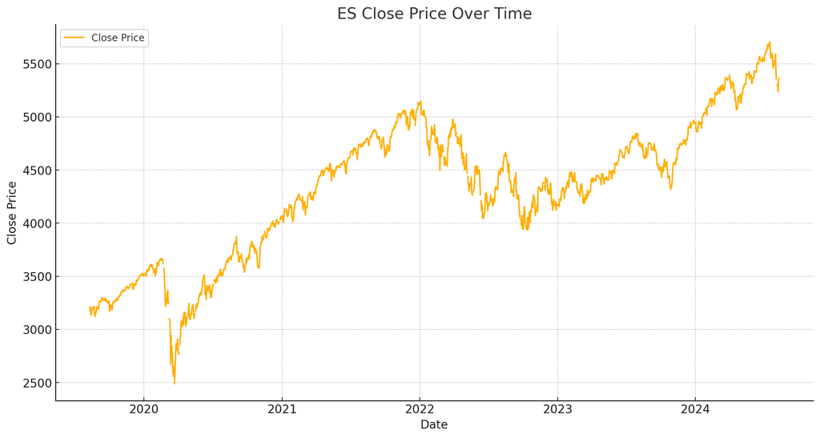

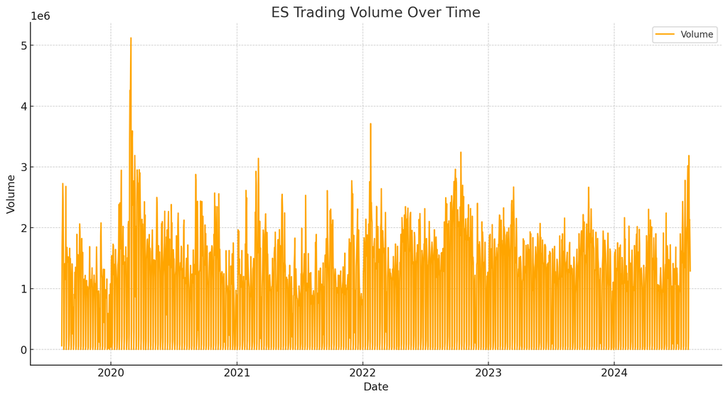

[figure not shown]

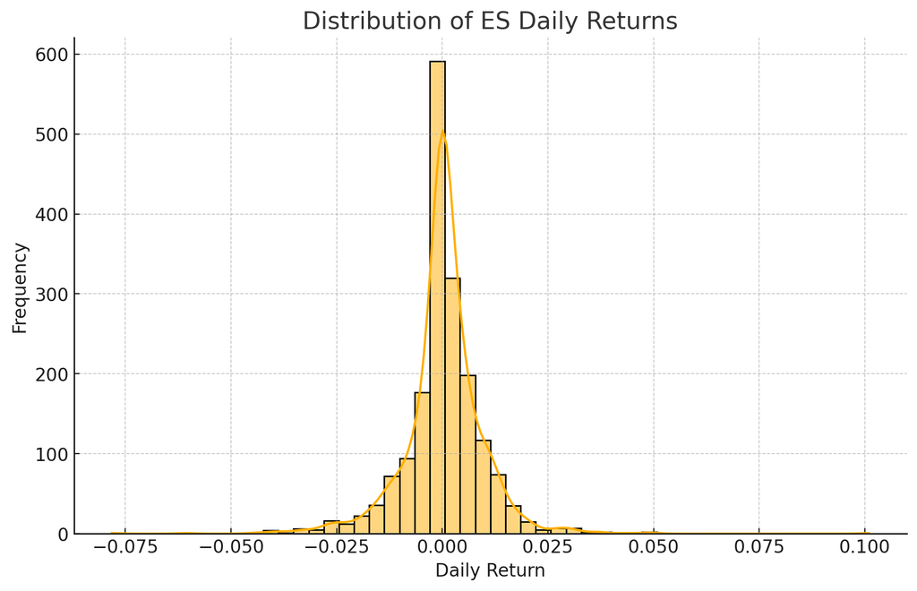

```python
# Convert Period index back to datetime for plotting
es_daily.index = es_daily.index.to_timestamp()

# Plotting ES Close Price over time
plt.figure(figsize=(14, 7))
plt.plot(es_daily['Close'], label='Close Price')
plt.title('ES Close Price Over Time')
plt.xlabel('Date')
plt.ylabel('Close Price')
plt.legend()
plt.show()

# Plotting ES Trading Volume over time
plt.figure(figsize=(14, 7))
plt.plot(es_daily['Volume'], label='Volume', color='orange')
plt.title('ES Trading Volume Over Time')
plt.xlabel('Date')
plt.ylabel('Volume')
plt.legend()
plt.show()

# Moving averages
es_daily['20_Day_MA'] = es_daily['Close'].rolling(window=20).mean()
es_daily['50_Day_MA'] = es_daily['Close'].rolling(window=50).mean()

plt.figure(figsize=(14, 7))
plt.plot(es_daily['Close'], label='Close Price')
plt.plot(es_daily['20_Day_MA'], label='20-Day Moving Average', linestyle='--')
plt.plot(es_daily['50_Day_MA'], label='50-Day Moving Average', linestyle='--')
plt.title('ES Close Price with Moving Averages')
plt.xlabel('Date')
plt.ylabel('Price')
plt.legend()
plt.show()

# Volatility Analysis: Daily Returns
plt.figure(figsize=(10, 6))
sns.histplot(es_daily['Daily Return'].dropna(), bins=50, kde=True)
plt.title('Distribution of ES Daily Returns')
plt.xlabel('Daily Return')
plt.ylabel('Frequency')
plt.show()
```

## Statistical Analysis

We perform statistical analysis to understand the relationships between different features in the ES dataset. This includes correlation analysis and analyzing the distribution of daily returns to identify major market movements.

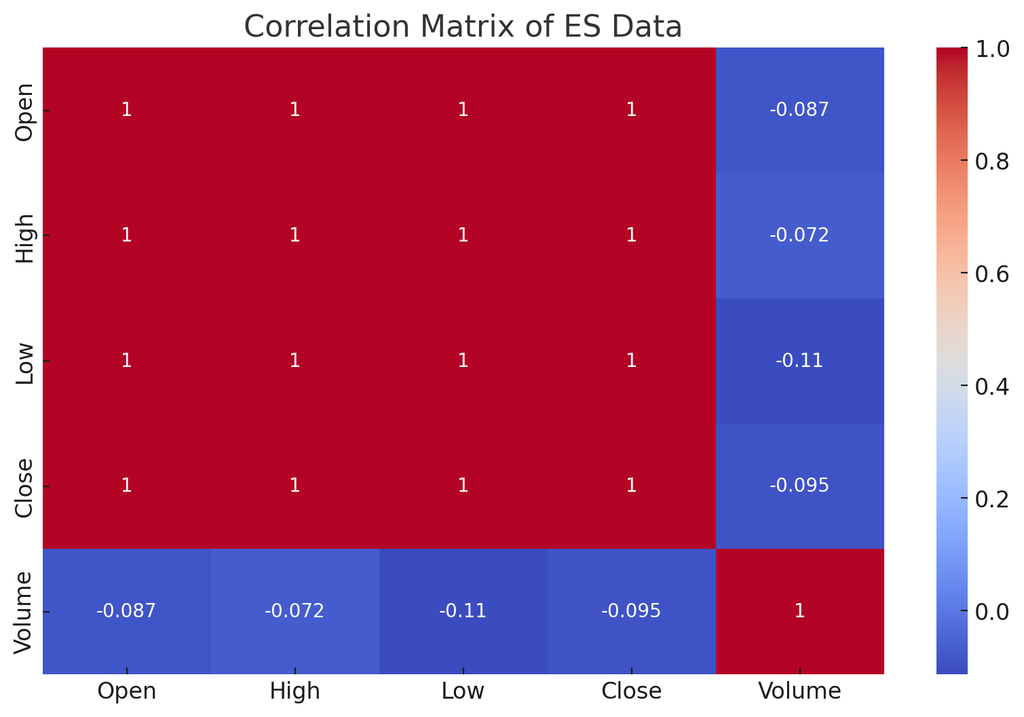

| Time | Close | Daily Return |
| --- | --- | --- |
| 2019-08-14 | 3132.00 | -0.024147 |
| 2019-08-23 | 3134.25 | -0.025192 |
| 2020-02-25 | 3429.00 | -0.028818 |
| 2020-02-26 | 3340.25 | -0.025882 |
| 2020-02-27 | 3216.75 | -0.036973 |
| ... | ... | ... |
| 2022-12-15 | 4232.75 | -0.024824 |
| 2023-03-09 | 4196.25 | -0.023844 |
| 2023-11-14 | 4702.50 | 0.020231 |
| 2024-08-01 | 5440.75 | -0.026874 |
| 2024-08-08 | 5354.25 | 0.022682 |

90 rows × 2 columns

```python
# Correlation analysis
correlation_matrix = es_daily[['Open', 'High', 'Low', 'Close', 'Volume']].corr()
plt.figure(figsize=(10, 6))
sns.heatmap(correlation_matrix, annot=True, cmap='coolwarm')
plt.title('Correlation Matrix of ES Data')
plt.show()

# Analyzing major market movements
significant_changes = es_daily[es_daily['Daily Return'].abs() > 0.02]
significant_changes[['Close', 'Daily Return']]
```

## Predictive Modeling

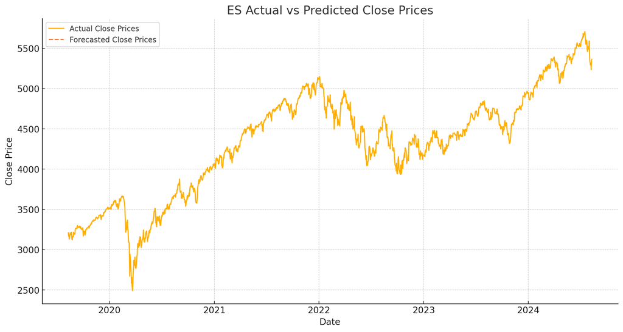

```python
# Prepare data for ARIMA model
es_close = es_daily['Close'].dropna()

# Fit ARIMA model
model = ARIMA(es_close, order=(5, 1, 0))
arima_result = model.fit()

# Predict future values
es_daily['Forecast'] = arima_result.predict(start=len(es_close), end=len(es_close) + 30, dynamic=True)

# Plot actual vs predicted
plt.figure(figsize=(14, 7))
plt.plot(es_close, label='Actual Close Prices')
plt.plot(es_daily['Forecast'], label='Forecasted Close Prices', linestyle='--')
plt.title('ES Actual vs Predicted Close Prices')
plt.xlabel('Date')
plt.ylabel('Close Price')
plt.legend()
plt.show()
```

## Conclusion

### Final Thoughts:

Continuous monitoring and modeling adjustments are crucial for capturing the market's behavior accurately. Including external factors such as macroeconomic indicators and sentiment analysis could further enhance forecasting models.